# Risk Factor Analysis

## Outcome Variable

**Outcome Variable:** whz

## Predictor Variables

**Intervention Variable:** studyid

**Adjustment Set:**

unadjusted

## Stratifying Variables

The analysis was stratified on these variable(s):

- agecat

## Data Summary

| agecat | studyid | n_cell | n |
| --- | --- | --- | --- |
| Birth | ki0047075b-MAL-ED | 1450 | 56639 |
| Birth | ki1000108-CMC-V-BCS-2002 | 88 | 56639 |
| Birth | ki1000108-IRC | 343 | 56639 |
| Birth | ki1000109-EE | 1 | 56639 |
| Birth | ki1000109-ResPak | 6 | 56639 |
| Birth | ki1000304b-SAS-CompFeed | 166 | 56639 |
| Birth | ki1000304b-SAS-FoodSuppl | 0 | 56639 |
| Birth | ki1017093-NIH-Birth | 28 | 56639 |
| Birth | ki1017093b-PROVIDE | 0 | 56639 |
| Birth | ki1017093c-NIH-Crypto | 23 | 56639 |
| Birth | ki1066203-TanzaniaChild2 | 0 | 56639 |
| Birth | ki1101329-Keneba | 1423 | 56639 |
| Birth | ki1112895-Guatemala BSC | 0 | 56639 |
| Birth | ki1113344-GMS-Nepal | 0 | 56639 |
| Birth | ki1114097-CMIN | 129 | 56639 |
| Birth | ki1114097-CONTENT | 2 | 56639 |
| Birth | ki1119695-PROBIT | 13824 | 56639 |
| Birth | ki1126311-ZVITAMBO | 12916 | 56639 |
| Birth | ki1135781-COHORTS | 9848 | 56639 |
| Birth | ki1148112-LCNI-5 | 0 | 56639 |
| Birth | kiGH5241-JiVitA-3 | 15709 | 56639 |
| Birth | kiGH5241-JiVitA-4 | 683 | 56639 |
| 6 months | ki0047075b-MAL-ED | 1696 | 70656 |
| 6 months | ki1000108-CMC-V-BCS-2002 | 368 | 70656 |
| 6 months | ki1000108-IRC | 408 | 70656 |
| 6 months | ki1000109-EE | 376 | 70656 |
| 6 months | ki1000109-ResPak | 235 | 70656 |
| 6 months | ki1000304b-SAS-CompFeed | 1334 | 70656 |
| 6 months | ki1000304b-SAS-FoodSuppl | 380 | 70656 |
| 6 months | ki1017093-NIH-Birth | 536 | 70656 |
| 6 months | ki1017093b-PROVIDE | 582 | 70656 |
| 6 months | ki1017093c-NIH-Crypto | 715 | 70656 |
| 6 months | ki1066203-TanzaniaChild2 | 2028 | 70656 |
| 6 months | ki1101329-Keneba | 2089 | 70656 |
| 6 months | ki1112895-Guatemala BSC | 299 | 70656 |
| 6 months | ki1113344-GMS-Nepal | 563 | 70656 |
| 6 months | ki1114097-CMIN | 1836 | 70656 |
| 6 months | ki1114097-CONTENT | 215 | 70656 |
| 6 months | ki1119695-PROBIT | 15757 | 70656 |
| 6 months | ki1126311-ZVITAMBO | 8264 | 70656 |
| 6 months | ki1135781-COHORTS | 10519 | 70656 |
| 6 months | ki1148112-LCNI-5 | 839 | 70656 |
| 6 months | kiGH5241-JiVitA-3 | 16784 | 70656 |
| 6 months | kiGH5241-JiVitA-4 | 4833 | 70656 |
| 24 months | ki0047075b-MAL-ED | 1489 | 34524 |
| 24 months | ki1000108-CMC-V-BCS-2002 | 372 | 34524 |
| 24 months | ki1000108-IRC | 409 | 34524 |
| 24 months | ki1000109-EE | 0 | 34524 |
| 24 months | ki1000109-ResPak | 0 | 34524 |
| 24 months | ki1000304b-SAS-CompFeed | 0 | 34524 |
| 24 months | ki1000304b-SAS-FoodSuppl | 0 | 34524 |
| 24 months | ki1017093-NIH-Birth | 428 | 34524 |
| 24 months | ki1017093b-PROVIDE | 578 | 34524 |
| 24 months | ki1017093c-NIH-Crypto | 514 | 34524 |
| 24 months | ki1066203-TanzaniaChild2 | 6 | 34524 |
| 24 months | ki1101329-Keneba | 1726 | 34524 |
| 24 months | ki1112895-Guatemala BSC | 0 | 34524 |
| 24 months | ki1113344-GMS-Nepal | 498 | 34524 |
| 24 months | ki1114097-CMIN | 1223 | 34524 |
| 24 months | ki1114097-CONTENT | 164 | 34524 |
| 24 months | ki1119695-PROBIT | 3971 | 34524 |
| 24 months | ki1126311-ZVITAMBO | 423 | 34524 |
| 24 months | ki1135781-COHORTS | 8822 | 34524 |
| 24 months | ki1148112-LCNI-5 | 563 | 34524 |
| 24 months | kiGH5241-JiVitA-3 | 8603 | 34524 |
| 24 months | kiGH5241-JiVitA-4 | 4735 | 34524 |

The following strata were considered:

- agecat: 24 months
- agecat: 6 months
- agecat: Birth

### Dropped Strata

Some strata were dropped due to rare outcomes:

- agecat: Birth
- agecat: 24 months

## Methods Detail

We’re interested in the causal parameters $E[Y_a]$ for all values of $a \in \mathcal{A}$. These parameters represent the mean outcome if, possibly contrary to fact, we intervened to set all units to have $A=a$. Under the randomization and positivity assumptions, these are identified by the statistical parameters $\psi_a=E_W[E_{Y|A,W}(Y|A=a,W)]$. In addition, we’re interested in the mean of $Y$, $E[Y]$ under no intervention (the observed mean). We will estimate these parameters by using SuperLearner to fit the relevant likelihood factors – $E_{Y|A,W}(Y|A=a,W)$ and $p(A=a|W)$, and then updating our likelihood fit using a joint TMLE.

For unadjusted analyses ($W=\{\}$), initial likelihoods were estimated using Lrnr_glm to estimate the simple $E(Y|A)$ and Lrnr_mean to estimate $p(A)$. For adjusted analyses, a small library containing Lrnr_glmnet, Lrnr_xgboost, and Lrnr_mean was used.

Having estimated these parameters, we will then use the delta method to estimate relative risks and attributable risks relative to a prespecified baseline level of $A$.

# Results Detail

## Results Plots

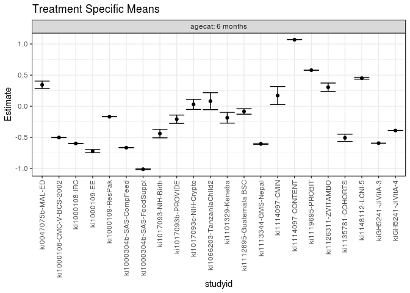

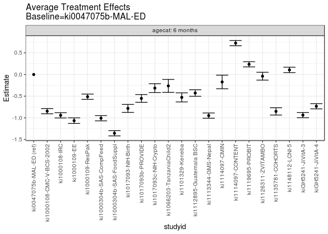

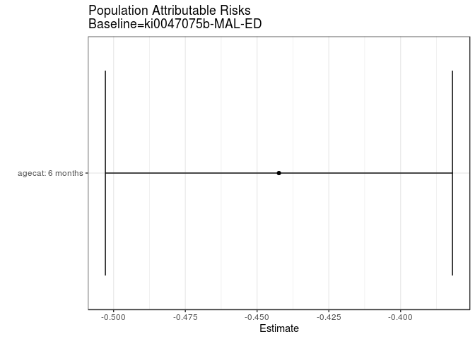

## Results Table

### Parameter: TSM

| agecat | intervention_level | baseline_level | estimate | ci_lower | ci_upper |
| --- | --- | --- | --- | --- | --- |
| 6 months | ki0047075b-MAL-ED | NA | 0.3436630 | 0.2833512 | 0.4039748 |
| 6 months | ki1000108-CMC-V-BCS-2002 | NA | -0.5026766 | -0.5048335 | -0.5005198 |
| 6 months | ki1000108-IRC | NA | -0.5989297 | -0.6010780 | -0.5967814 |
| 6 months | ki1000109-EE | NA | -0.7212766 | -0.7463655 | -0.6961877 |
| 6 months | ki1000109-ResPak | NA | -0.1683617 | -0.1699643 | -0.1667591 |
| 6 months | ki1000304b-SAS-CompFeed | NA | -0.6657084 | -0.6664654 | -0.6649514 |
| 6 months | ki1000304b-SAS-FoodSuppl | NA | -1.0121579 | -1.0176872 | -1.0066286 |
| 6 months | ki1017093-NIH-Birth | NA | -0.4389101 | -0.5080492 | -0.3697711 |
| 6 months | ki1017093b-PROVIDE | NA | -0.2083706 | -0.2749684 | -0.1417727 |
| 6 months | ki1017093c-NIH-Crypto | NA | 0.0297622 | -0.0518013 | 0.1113258 |
| 6 months | ki1066203-TanzaniaChild2 | NA | 0.0809332 | -0.0557556 | 0.2176220 |
| 6 months | ki1101329-Keneba | NA | -0.1846223 | -0.2713066 | -0.0979380 |
| 6 months | ki1112895-Guatemala BSC | NA | -0.0840134 | -0.1278715 | -0.0401552 |
| 6 months | ki1113344-GMS-Nepal | NA | -0.6047987 | -0.6150001 | -0.5945973 |
| 6 months | ki1114097-CMIN | NA | 0.1716267 | 0.0261921 | 0.3170614 |
| 6 months | ki1114097-CONTENT | NA | 1.0684318 | 1.0674681 | 1.0693955 |
| 6 months | ki1119695-PROBIT | NA | 0.5789633 | 0.5786880 | 0.5792386 |
| 6 months | ki1126311-ZVITAMBO | NA | 0.3047138 | 0.2368713 | 0.3725564 |
| 6 months | ki1135781-COHORTS | NA | -0.5077260 | -0.5664327 | -0.4490194 |
| 6 months | ki1148112-LCNI-5 | NA | 0.4499285 | 0.4348317 | 0.4650253 |
| 6 months | kiGH5241-JiVitA-3 | NA | -0.5935161 | -0.5946677 | -0.5923646 |
| 6 months | kiGH5241-JiVitA-4 | NA | -0.3898055 | -0.3917666 | -0.3878444 |

### Parameter: E(Y)

| agecat | intervention_level | baseline_level | estimate | ci_lower | ci_upper |
| --- | --- | --- | --- | --- | --- |
| 6 months | NA | NA | -0.0987239 | -0.1131619 | -0.0842858 |

### Parameter: ATE

| agecat | intervention_level | baseline_level | estimate | ci_lower | ci_upper |
| --- | --- | --- | --- | --- | --- |
| 6 months | ki0047075b-MAL-ED | ki0047075b-MAL-ED | 0.0000000 | 0.0000000 | 0.0000000 |
| 6 months | ki1000108-CMC-V-BCS-2002 | ki0047075b-MAL-ED | -0.8463397 | -0.9067011 | -0.7859782 |
| 6 months | ki1000108-IRC | ki0047075b-MAL-ED | -0.9425928 | -1.0029423 | -0.8822432 |
| 6 months | ki1000109-EE | ki0047075b-MAL-ED | -1.0649396 | -1.1296944 | -1.0001849 |
| 6 months | ki1000109-ResPak | ki0047075b-MAL-ED | -0.5120247 | -0.5723600 | -0.4516895 |
| 6 months | ki1000304b-SAS-CompFeed | ki0047075b-MAL-ED | -1.0093714 | -1.0696884 | -0.9490545 |
| 6 months | ki1000304b-SAS-FoodSuppl | ki0047075b-MAL-ED | -1.3558209 | -1.4164023 | -1.2952396 |
| 6 months | ki1017093-NIH-Birth | ki0047075b-MAL-ED | -0.7825732 | -0.8743220 | -0.6908244 |
| 6 months | ki1017093b-PROVIDE | ki0047075b-MAL-ED | -0.5520336 | -0.6418325 | -0.4622346 |
| 6 months | ki1017093c-NIH-Crypto | ki0047075b-MAL-ED | -0.3139008 | -0.4153414 | -0.2124602 |
| 6 months | ki1066203-TanzaniaChild2 | ki0047075b-MAL-ED | -0.2627298 | -0.4121332 | -0.1133265 |
| 6 months | ki1101329-Keneba | ki0047075b-MAL-ED | -0.5282854 | -0.6334432 | -0.4231275 |
| 6 months | ki1112895-Guatemala BSC | ki0047075b-MAL-ED | -0.4276764 | -0.5024262 | -0.3529267 |
| 6 months | ki1113344-GMS-Nepal | ki0047075b-MAL-ED | -0.9484617 | -1.0093726 | -0.8875508 |
| 6 months | ki1114097-CMIN | ki0047075b-MAL-ED | -0.1720363 | -0.3294815 | -0.0145911 |
| 6 months | ki1114097-CONTENT | ki0047075b-MAL-ED | 0.7247688 | 0.6644506 | 0.7850869 |
| 6 months | ki1119695-PROBIT | ki0047075b-MAL-ED | 0.2353003 | 0.1749878 | 0.2956128 |
| 6 months | ki1126311-ZVITAMBO | ki0047075b-MAL-ED | -0.0389492 | -0.1297242 | 0.0518258 |
| 6 months | ki1135781-COHORTS | ki0047075b-MAL-ED | -0.8513891 | -0.9355555 | -0.7672226 |
| 6 months | ki1148112-LCNI-5 | ki0047075b-MAL-ED | 0.1062655 | 0.0438701 | 0.1686608 |
| 6 months | kiGH5241-JiVitA-3 | ki0047075b-MAL-ED | -0.9371792 | -0.9975008 | -0.8768575 |
| 6 months | kiGH5241-JiVitA-4 | ki0047075b-MAL-ED | -0.7334685 | -0.7938162 | -0.6731208 |

### Parameter: PAR

| agecat | intervention_level | baseline_level | estimate | ci_lower | ci_upper |
| --- | --- | --- | --- | --- | --- |
| 6 months | ki0047075b-MAL-ED | NA | -0.4423869 | -0.5028574 | -0.3819164 |